# Explore Bike Share Data

```r
# Uses the ggplot2 to plots the charts
library(ggplot2)
```

```r
# Read the .csv files and assigns to each data frame.
ny = read.csv('new_york_city.csv')
wash = read.csv('washington.csv')
chi = read.csv('chicago.csv')
```

```r
# Print out the data frame for New York City to check
head(ny)
```

| X | Start.Time | End.Time | Trip.Duration | Start.Station | End.Station | User.Type | Gender | Birth.Year |
| --- | --- | --- | --- | --- | --- | --- | --- | --- |
| 5688089 | 2017-06-11 14:55:05 | 2017-06-11 15:08:21 | 795 | Suffolk St & Stanton St | W Broadway & Spring St | Subscriber | Male | 1998 |
| 4096714 | 2017-05-11 15:30:11 | 2017-05-11 15:41:43 | 692 | Lexington Ave & E 63 St | 1 Ave & E 78 St | Subscriber | Male | 1981 |
| 2173887 | 2017-03-29 13:26:26 | 2017-03-29 13:48:31 | 1325 | 1 Pl & Clinton St | Henry St & Degraw St | Subscriber | Male | 1987 |
| 3945638 | 2017-05-08 19:47:18 | 2017-05-08 19:59:01 | 703 | Barrow St & Hudson St | W 20 St & 8 Ave | Subscriber | Female | 1986 |
| 6208972 | 2017-06-21 07:49:16 | 2017-06-21 07:54:46 | 329 | 1 Ave & E 44 St | E 53 St & 3 Ave | Subscriber | Male | 1992 |
| 1285652 | 2017-02-22 18:55:24 | 2017-02-22 19:12:03 | 998 | State St & Smith St | Bond St & Fulton St | Subscriber | Male | 1986 |

```r
# Print out the dataframe for Washington City to check
head(wash)
```

| X | Start.Time | End.Time | Trip.Duration | Start.Station | End.Station | User.Type |
| --- | --- | --- | --- | --- | --- | --- |
| 1621326 | 2017-06-21 08:36:34 | 2017-06-21 08:44:43 | 489.066 | 14th & Belmont St NW | 15th & K St NW | Subscriber |
| 482740 | 2017-03-11 10:40:00 | 2017-03-11 10:46:00 | 402.549 | Yuma St & Tenley Circle NW | Connecticut Ave & Yuma St NW | Subscriber |
| 1330037 | 2017-05-30 01:02:59 | 2017-05-30 01:13:37 | 637.251 | 17th St & Massachusetts Ave NW | 5th & K St NW | Subscriber |
| 665458 | 2017-04-02 07:48:35 | 2017-04-02 08:19:03 | 1827.341 | Constitution Ave & 2nd St NW/DOL | M St & Pennsylvania Ave NW | Customer |
| 1481135 | 2017-06-10 08:36:28 | 2017-06-10 09:02:17 | 1549.427 | Henry Bacon Dr & Lincoln Memorial Circle NW | Maine Ave & 7th St SW | Subscriber |
| 1148202 | 2017-05-14 07:18:18 | 2017-05-14 07:24:56 | 398.000 | 1st & K St SE | Eastern Market Metro / Pennsylvania Ave & 7th St SE | Subscriber |

```r
# Print out the dataframe for Chicago City to check
head(chi)
```

| X | Start.Time | End.Time | Trip.Duration | Start.Station | End.Station | User.Type | Gender | Birth.Year |
| --- | --- | --- | --- | --- | --- | --- | --- | --- |
| 1423854 | 2017-06-23 15:09:32 | 2017-06-23 15:14:53 | 321 | Wood St & Hubbard St | Damen Ave & Chicago Ave | Subscriber | Male | 1992 |
| 955915 | 2017-05-25 18:19:03 | 2017-05-25 18:45:53 | 1610 | Theater on the Lake | Sheffield Ave & Waveland Ave | Subscriber | Female | 1992 |
| 9031 | 2017-01-04 08:27:49 | 2017-01-04 08:34:45 | 416 | May St & Taylor St | Wood St & Taylor St | Subscriber | Male | 1981 |
| 304487 | 2017-03-06 13:49:38 | 2017-03-06 13:55:28 | 350 | Christiana Ave & Lawrence Ave | St. Louis Ave & Balmoral Ave | Subscriber | Male | 1986 |
| 45207 | 2017-01-17 14:53:07 | 2017-01-17 15:02:01 | 534 | Clark St & Randolph St | Desplaines St & Jackson Blvd | Subscriber | Male | 1975 |
| 1473887 | 2017-06-26 09:01:20 | 2017-06-26 09:11:06 | 586 | Clinton St & Washington Blvd | Canal St & Taylor St | Subscriber | Male | 1990 |

# Question 1

### What are the common days and hours during a week when people choose to use shared bikes to commute? And what the potential purpose of the use? ( in Washington City).

**Using the bike-share data from Washington to gain the insight:**

- Step 1: Observe and convert the "Start.Time" in Washington data frame to DateTime format.
- Step 2: Extract the day of the week values from the "Start.Time" and add it to the new column name "DayOfWeek".
- Step 3: Re-order the values in the "DayOfWeek" column from Monday - Sunday.
- Step 4: Use a barplot and lineplot to demonstrate the difference in each day of the week.
- Step 5: Extract the hour values from the "Start.Time" and add it to the new column name "Hour."
- Step 6: Use the histogram and line to plot the Hour column to see the most common hours people used the bike.
- Step 7: (Conclusion from the result charts) 📊

```r
# Step 1: (1.1)
# Creates a copy "wa" from the original data set "wash".

wa <- wash
```

```r
# Step 1: (1.2)
# Prints out the first five rows to observe the values.

head(wa,5)
```

| X | Start.Time | End.Time | Trip.Duration | Start.Station | End.Station | User.Type |
| --- | --- | --- | --- | --- | --- | --- |
| 1621326 | 2017-06-21 08:36:34 | 2017-06-21 08:44:43 | 489.066 | 14th & Belmont St NW | 15th & K St NW | Subscriber |
| 482740 | 2017-03-11 10:40:00 | 2017-03-11 10:46:00 | 402.549 | Yuma St & Tenley Circle NW | Connecticut Ave & Yuma St NW | Subscriber |
| 1330037 | 2017-05-30 01:02:59 | 2017-05-30 01:13:37 | 637.251 | 17th St & Massachusetts Ave NW | 5th & K St NW | Subscriber |
| 665458 | 2017-04-02 07:48:35 | 2017-04-02 08:19:03 | 1827.341 | Constitution Ave & 2nd St NW/DOL | M St & Pennsylvania Ave NW | Customer |
| 1481135 | 2017-06-10 08:36:28 | 2017-06-10 09:02:17 | 1549.427 | Henry Bacon Dr & Lincoln Memorial Circle NW | Maine Ave & 7th St SW | Subscriber |

```r
# Step 1: (1.3)
# Check the current data type of the "Start.Time" column.

typeof(wa$Start.Time)
```

'integer'

```r
# Step 1: (1.3)
# Uses the as.POSIXct() function to convert the int format to datatime format.

wa$Start.Time <- as.POSIXct(wa$Start.Time, format = "%Y-%m-%d %H:%M:%S")
```

```r
# Step 1: (1.4)
# Re-check the result from the convert (the 'datetime' data type in R is stored as 'double' format)

typeof(wa$Start.Time)
```

'double'

```r
# Step 2: (2.1)
# Extracts the day of a week by using the weekdays() function and store values in the DayOfWeek column.

wa$DayOfWeek <- weekdays(wa$Start.Time)
```

```r
# Step 2: (2.2)
# Check the result by print out values in the DayOfWeek column

head(wa$DayOfWeek,5)
```

1. 'Wednesday'

2. 'Saturday'

3. 'Tuesday'

4. 'Sunday'

5. 'Saturday'

```r
# Step 3: (3.1)
# Uses the factor() function to re-order the day in a week from Monday - Sunday.

wa$DayOfWeek <- factor(wa$DayOfWeek, levels = c("Monday","Tuesday","Wednesday","Thursday",
                                                    "Friday", "Saturday","Sunday"))
```

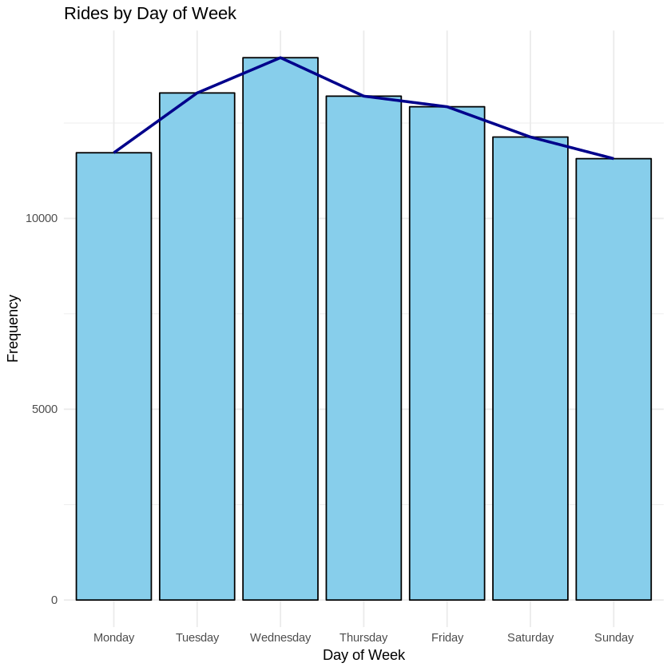

```r
# Step 4: (4.1)
# Uses the ggpot() function to plot the total amount of each day in week to the bar chart to see the different.

# Uses the subset() to eliminate all the na values in the column.
ggplot(data = subset(wa, !is.na(DayOfWeek)), aes(x = DayOfWeek)) +
  geom_bar(fill = "skyblue", color = "black") +
  geom_line(aes(group = 1), stat = "count", color = "darkblue", size = 1) +
  labs(title = "Rides by Day of Week", x = "Day of Week", y = "Frequency") +
  theme_minimal()
```

```r
# Step 5: (5.1)
# Uses the as.numeric() function to extract the hour values from the Start.Time column.
# Stores the extracted values to the new column name "Hour"

wa$Hour <- as.numeric(format(wa$Start.Time, "%H"))
```

```r
# Step 5: (5.2)
# Print out values in the Hour column to confirm the extracting processs above.

head(wa$Hour,5)
```

1. 8

2. 10

3. 1

4. 7

5. 8

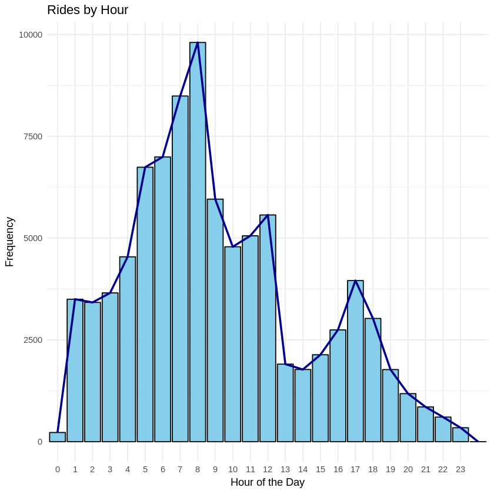

```r
# Step 6: (6.1)
# Uses the bar chart to show the comparision for each hour of a day.
# Uses the factor() function to organize the values in the chart.

ggplot(wa, aes(x = factor(Hour, levels = 0:23))) +
  geom_bar(fill = "skyblue", color = "black") +
  geom_line(aes(group = 1), stat = "count", color = "darkblue", size = 1) +
  scale_x_discrete(name = "Hour of the Day", breaks = 0:23, labels = 0:23) +
  labs(title = "Rides by Hour", y = "Frequency") +
  theme_minimal()
```

```r
# Step 6: (6.1)
# Using the table() fucntion to see the statistical numbers in total of each hour of a day and day in a week.

table(wa$Hour)
table(wa$DayOfWeek)
```

```
   0    1    2    3    4    5    6    7    8    9   10   11   12   13   14   15
 227 3500 3421 3655 4541 6741 6994 8490 9805 5957 4788 5057 5569 1906 1774 2136
  16   17   18   19   20   21   22   23
2746 3958 3028 1772 1181  855  605  344
```

```
   Monday   Tuesday Wednesday  Thursday    Friday  Saturday    Sunday
    11721     13288     14212     13204     12926     12133     11566
```

### Step 7: (Conclusion)

**Summary**: Both illustrations show that people mostly use the bike to commute to work, usually before 9 a.m., and go home around 5 p.m. on weekdays.

# Question 2

### What is the average time spent renting a bike in three different cities? (New York, Chicago, and Washington cities)

**General main steps to compare the average use of bikes in three cities:**

- Step 1: Assign the copy data frame from the original data frame.
- Step 2: Convert the "Trip.Duration" columns to the same datatype (int).
- Step 3: Create the new column "City" for each data frame to distinguish the difference between each city.
- Step 4: Create the data frame for each data set that only contains the columns "Trip.Duration" and city out from each current dataset.
- Step 5: Combine the three new data frames into one.
- Step 6: Plot the combined data frame to boxplot for comparison
- Step 7: Conclusion from the research.

```r
# Step 1: (1.1)
# Assigns three new dataframes from the original dataframes

ny.copy <- ny    #The New York dataset
wa.copy <- wash  #The Washington dataset
chi.copy <- chi  #The Chicago dataset
```

```r
# Step 1: (1.2)
# Print the first 5 rows to check the new dataframe

head(ny.copy,5)
```

| X | Start.Time | End.Time | Trip.Duration | Start.Station | End.Station | User.Type | Gender | Birth.Year |
| --- | --- | --- | --- | --- | --- | --- | --- | --- |
| 5688089 | 2017-06-11 14:55:05 | 2017-06-11 15:08:21 | 795 | Suffolk St & Stanton St | W Broadway & Spring St | Subscriber | Male | 1998 |
| 4096714 | 2017-05-11 15:30:11 | 2017-05-11 15:41:43 | 692 | Lexington Ave & E 63 St | 1 Ave & E 78 St | Subscriber | Male | 1981 |
| 2173887 | 2017-03-29 13:26:26 | 2017-03-29 13:48:31 | 1325 | 1 Pl & Clinton St | Henry St & Degraw St | Subscriber | Male | 1987 |
| 3945638 | 2017-05-08 19:47:18 | 2017-05-08 19:59:01 | 703 | Barrow St & Hudson St | W 20 St & 8 Ave | Subscriber | Female | 1986 |
| 6208972 | 2017-06-21 07:49:16 | 2017-06-21 07:54:46 | 329 | 1 Ave & E 44 St | E 53 St & 3 Ave | Subscriber | Male | 1992 |

```r
# Step 1: (1.3)
# Print the first 5 rows to check the new dataframe

head(wa.copy,5)
```

| X | Start.Time | End.Time | Trip.Duration | Start.Station | End.Station | User.Type |
| --- | --- | --- | --- | --- | --- | --- |
| 1621326 | 2017-06-21 08:36:34 | 2017-06-21 08:44:43 | 489.066 | 14th & Belmont St NW | 15th & K St NW | Subscriber |
| 482740 | 2017-03-11 10:40:00 | 2017-03-11 10:46:00 | 402.549 | Yuma St & Tenley Circle NW | Connecticut Ave & Yuma St NW | Subscriber |
| 1330037 | 2017-05-30 01:02:59 | 2017-05-30 01:13:37 | 637.251 | 17th St & Massachusetts Ave NW | 5th & K St NW | Subscriber |
| 665458 | 2017-04-02 07:48:35 | 2017-04-02 08:19:03 | 1827.341 | Constitution Ave & 2nd St NW/DOL | M St & Pennsylvania Ave NW | Customer |
| 1481135 | 2017-06-10 08:36:28 | 2017-06-10 09:02:17 | 1549.427 | Henry Bacon Dr & Lincoln Memorial Circle NW | Maine Ave & 7th St SW | Subscriber |

```r
# Step 1: (1.4)
# Print the first 5 rows to check the new dataframe

head(chi.copy,5)
```

| X | Start.Time | End.Time | Trip.Duration | Start.Station | End.Station | User.Type | Gender | Birth.Year |
| --- | --- | --- | --- | --- | --- | --- | --- | --- |
| 1423854 | 2017-06-23 15:09:32 | 2017-06-23 15:14:53 | 321 | Wood St & Hubbard St | Damen Ave & Chicago Ave | Subscriber | Male | 1992 |
| 955915 | 2017-05-25 18:19:03 | 2017-05-25 18:45:53 | 1610 | Theater on the Lake | Sheffield Ave & Waveland Ave | Subscriber | Female | 1992 |
| 9031 | 2017-01-04 08:27:49 | 2017-01-04 08:34:45 | 416 | May St & Taylor St | Wood St & Taylor St | Subscriber | Male | 1981 |
| 304487 | 2017-03-06 13:49:38 | 2017-03-06 13:55:28 | 350 | Christiana Ave & Lawrence Ave | St. Louis Ave & Balmoral Ave | Subscriber | Male | 1986 |
| 45207 | 2017-01-17 14:53:07 | 2017-01-17 15:02:01 | 534 | Clark St & Randolph St | Desplaines St & Jackson Blvd | Subscriber | Male | 1975 |

```r
# Step 2: (2.1)
# Convert the double type to int in wa.copy
wa.copy$Trip.Duration <- as.integer(wa.copy$Trip.Duration)
```

```r
# Step 2: (2.2)
# Check the convert process

typeof(wa.copy$Trip.Duration)
```

'integer'

```r
# Step 3: (3.1)
# Add columns "City" with the value "Washington" into the Washington city dataset.

wa.copy$City <- "Washington"
```

```r
# Step 3: (3.2)
# Add columns "City" with the value "New York" into the New York city dataset.

ny.copy$City <- "New York"
```

```r
# Step 3: (3.3)
# Add columns "City" with the value "Chicago" into the Chicago city dataset.

chi.copy$City <- "Chicago"
```

```r
# Step 4: (4.1)
# Creates the new three dataframes only contain the "City" and "Trip.Duration" from
# each dataframe

wa.merge <- wa.copy[,c("Trip.Duration","City")]
chi.merge <- chi.copy[,c("Trip.Duration","City")]
ny.merge <- ny.copy[,c("Trip.Duration","City")]
```

```r
# Step 4: (4.2)
# Check on the new dataframe

head(wa.merge,5)
head(chi.merge,5)
head(ny.merge,5)
```

| Trip.Duration | City |
| --- | --- |
| 489 | Washington |
| 402 | Washington |
| 637 | Washington |
| 1827 | Washington |
| 1549 | Washington |

| Trip.Duration | City |
| --- | --- |
| 321 | Chicago |
| 1610 | Chicago |
| 416 | Chicago |
| 350 | Chicago |
| 534 | Chicago |

| Trip.Duration | City |
| --- | --- |
| 795 | New York |
| 692 | New York |
| 1325 | New York |
| 703 | New York |
| 329 | New York |

```r
# Step 5: (5.1)
# Combines those three new datasets into "combined_cities" dataset.
combined_cities <- rbind(wa.merge, chi.merge, ny.merge)
```

```r
# Step 5: (5.2)
# Uses dim() function to check the result from the combination.

dim(combined_cities)
```

1. 152451

2. 2

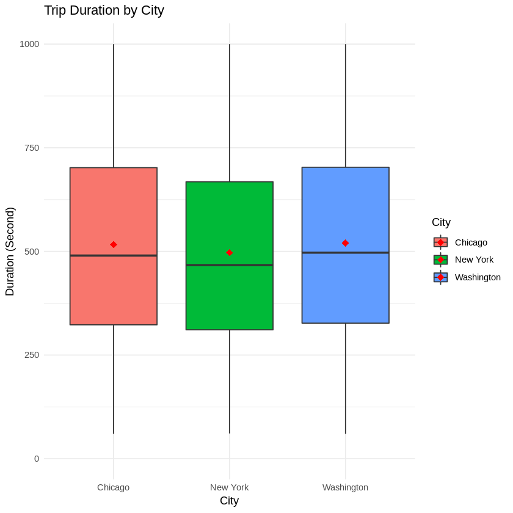

```r
# Step 6: (6.1)
# Using the qplot() to plot the three cities into three different boxplot.
# Uses the ylim() to limit the range containing the average duration in each city. Otherwise,
# The charts contain many ouliers values.

ggplot(combined_cities, aes(x = City, y = Trip.Duration, fill = City)) +
  geom_boxplot() + # Create the boxplot
  stat_summary(fun = mean, geom = "point", color = "red", size = 3, shape = 18) +
  ylim(0, 1000) +
  labs(title = "Trip Duration by City", x = "City", y = "Duration (Second)")+
  theme_minimal()
```

### Step 7: Conclusion

**Summary**: People will use their bikes to commute to their destinations, mostly in less than 10 minutes.

# Question 3

### What is the count of each gender? (NYC and Chicago cities)

General main steps to get to compare the amount of user gender in New York and Chicago cities:

- Step 1: Use the copied dataset of NYC and Chicago above to find the answer to this question.
- Step 2: Create two new datasets containing the "City" and "gender" columns.
- Step 3: Combine the two new datasets into a **combined_cities2** dataset.
- Step 4: Plots the **combined_cities2** dataset.
- Step 5: Conclusion.

```r
# Step 1: (1.1)
# Print out to check the dataset of New York and Chicago cities from the previous task.

head(ny.copy,3)
head(chi.copy,3)
```

| X | Start.Time | End.Time | Trip.Duration | Start.Station | End.Station | User.Type | Gender | Birth.Year | City |
| --- | --- | --- | --- | --- | --- | --- | --- | --- | --- |
| 5688089 | 2017-06-11 14:55:05 | 2017-06-11 15:08:21 | 795 | Suffolk St & Stanton St | W Broadway & Spring St | Subscriber | Male | 1998 | New York |
| 4096714 | 2017-05-11 15:30:11 | 2017-05-11 15:41:43 | 692 | Lexington Ave & E 63 St | 1 Ave & E 78 St | Subscriber | Male | 1981 | New York |
| 2173887 | 2017-03-29 13:26:26 | 2017-03-29 13:48:31 | 1325 | 1 Pl & Clinton St | Henry St & Degraw St | Subscriber | Male | 1987 | New York |

| X | Start.Time | End.Time | Trip.Duration | Start.Station | End.Station | User.Type | Gender | Birth.Year | City |
| --- | --- | --- | --- | --- | --- | --- | --- | --- | --- |
| 1423854 | 2017-06-23 15:09:32 | 2017-06-23 15:14:53 | 321 | Wood St & Hubbard St | Damen Ave & Chicago Ave | Subscriber | Male | 1992 | Chicago |
| 955915 | 2017-05-25 18:19:03 | 2017-05-25 18:45:53 | 1610 | Theater on the Lake | Sheffield Ave & Waveland Ave | Subscriber | Female | 1992 | Chicago |
| 9031 | 2017-01-04 08:27:49 | 2017-01-04 08:34:45 | 416 | May St & Taylor St | Wood St & Taylor St | Subscriber | Male | 1981 | Chicago |

```r
# Step 2: (2.1)
# Creates two new datasets for each city containing the "Gender" and "City" columns
ny.merge2 <- ny.copy[,c("Gender","City")]
chi.merge2 <- chi.copy[,c("Gender","City")]
```

```r
# Step 3: (3.1)
# Combines those two new dataframes and assigns to combined_cities2
combined_cities2 <- rbind(ny.merge2,chi.merge2)
```

```r
# Step 3: (3.2)
# Print out to see the first couple rows in the combined dataframe
head(combined_cities2,5)
```

| Gender | City |
| --- | --- |
| Male | New York |
| Male | New York |
| Male | New York |
| Female | New York |
| Male | New York |

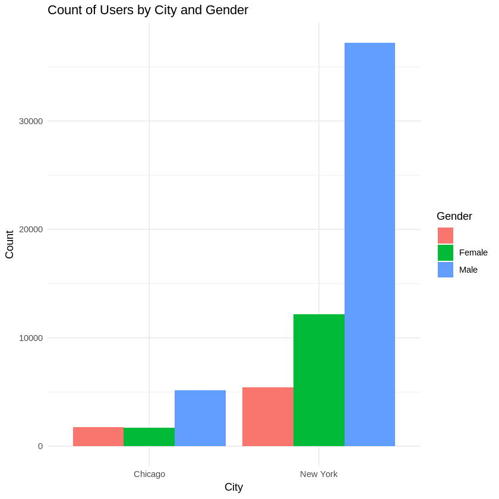

```r
# Step 4: (4.1)
# Uses the bar chart to demonstrate the different of genders

ggplot(combined_cities2,aes(x=City, fill=Gender)) +
geom_bar(position="dodge")+
labs(title = "Count of Users by City and Gender", x = "City", y = "Count")+
theme_minimal()
```

```r
# Step 4: (4.2)
# Use table() function to get the statistical values from the combined_cities2 data frame

table(combined_cities2$Gender)
```

```
       Female   Male
  7158  13882  42360
```

### Step 5: Conclusion

**Summary:** The BikeShare company can utilize this insight to target the next marketing campaign.

```r
system('python -m nbconvert Explore_bikeshare_data.ipynb')
```